# Simple Linear Regression

From Theory to Practice in R

Econometrics - Nova SBE

## Roadmap

In the previous lectures we covered the algebra of Simple Linear Regression on the whiteboard.

Today we bring it to life with **data, code, and simulations**.

0. Kaggle
1. Quick R warm-up
2. Exploring a real dataset
3. The OLS estimator — **by hand**
4. Using `lm()` — R does it for us
5. Inference — **by hand** vs. `summary()`
6. ⭐ **Simulation:** $\hat{\beta}_1$ is a random variable
7. What affects precision?
8. Residual diagnostics
9. Confidence and prediction bands

## This lecture

[figure not shown]

```r
library(qrcode)

plot(qr_code('https://pfagandini.github.io/novasbe_econometrics/R_SLR_Lecture_Slides.html'))
```

# Part 0: Kaggle

## Kaggle

Go to this website, and login however you like, I log in with my google account.

[figure not shown]

https://www.kaggle.com

## Kaggle

Click in “Create”

[figure not shown]

And select “Notebook”

## Kaggle

Sometimes it defaults to Python, but it learns your preference (use R often and it will start creating R notebooks by default)

To check/set an R environment:

1. Go to the **File** menu
2. Select **Language**
3. Chose **R**
4. Click the **Start Session** icon (a circle with a vertical line, top right corner of the *notebook*)

# Part I: R Basics

## Vectors: the building block of R

```r
# A vector is the most basic data structure in R
x <- c(1, 2, 3, 4, 5)
x
```

```
[1] 1 2 3 4 5
```

```r
# R is vectorized: operations apply element by element
x^2
```

```
[1]  1  4  9 16 25
```

```r
# Summary statistics
cat("Mean:", mean(x), " | Variance:", var(x), " | Std Dev:", sd(x), "\n")
```

```
Mean: 3  | Variance: 2.5  | Std Dev: 1.581139
```

**Note**

`var()` uses $n-1$ (sample variance), not $n$.

## Quick plotting

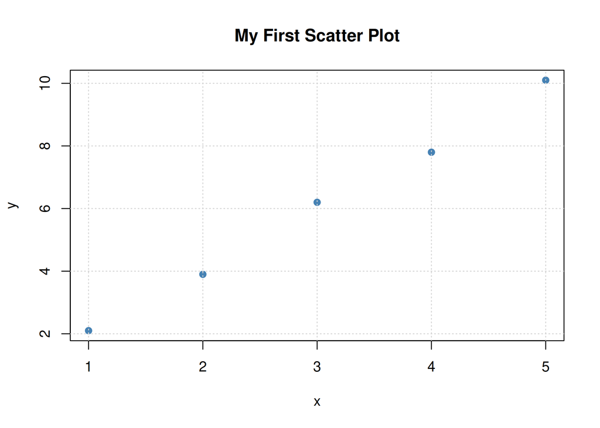

```r
y <- c(2.1, 3.9, 6.2, 7.8, 10.1)

plot(x, y, pch = 19, col = "steelblue",
     main = "My First Scatter Plot", xlab = "x", ylab = "y")
grid()
```

# Part II: A Real Dataset

## The `mtcars` dataset

Built into R: data on 32 automobiles (1974 Motor Trend magazine).

**Our question:** *How does the weight of a car affect its fuel consumption?*

$$\text{mpg}_i = \beta_0 + \beta_1 \cdot \text{wt}_i + u_i$$

```r
data(mtcars)
head(mtcars[, c("mpg", "wt", "hp", "cyl")], 8)
```

```
                   mpg    wt  hp cyl
Mazda RX4         21.0 2.620 110   6
Mazda RX4 Wag     21.0 2.875 110   6
Datsun 710        22.8 2.320  93   4
Hornet 4 Drive    21.4 3.215 110   6
Hornet Sportabout 18.7 3.440 175   8
Valiant           18.1 3.460 105   6
Duster 360        14.3 3.570 245   8
Merc 240D         24.4 3.190  62   4
```

## Descriptive statistics

```r
y <- mtcars$mpg   # miles per gallon (dependent variable)
x <- mtcars$wt    # weight in 1000 lbs (independent variable)
```

```r
summary(y)
```

```
   Min. 1st Qu.  Median    Mean 3rd Qu.    Max.
  10.40   15.43   19.20   20.09   22.80   33.90
```

```r
summary(x)
```

```
   Min. 1st Qu.  Median    Mean 3rd Qu.    Max.
  1.513   2.581   3.325   3.217   3.610   5.424
```

## Visual exploration

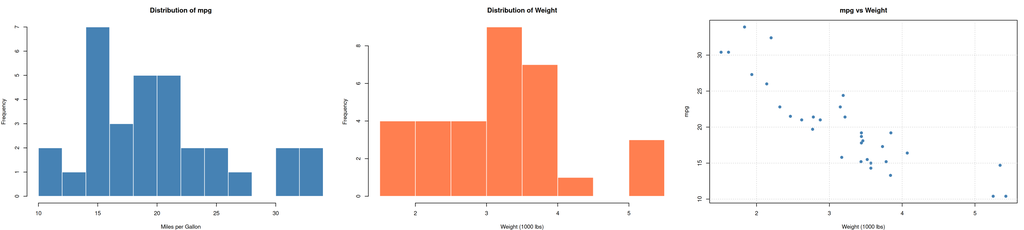

```r
par(mfrow = c(1, 3), mar = c(4, 4, 3, 1))

hist(y, breaks = 10, col = "steelblue", border = "white",
     main = "Distribution of mpg", xlab = "Miles per Gallon")

hist(x, breaks = 10, col = "coral", border = "white",
     main = "Distribution of Weight", xlab = "Weight (1000 lbs)")

plot(x, y, pch = 19, col = "steelblue",
     main = "mpg vs Weight", xlab = "Weight (1000 lbs)", ylab = "mpg")
grid()
```

## Correlation

```r
cor(x, y)
```

```
[1] -0.8676594
```

**Strong negative linear relationship.** Heavier cars tend to have lower fuel efficiency.

> **Question:** Looking at the scatter plot, does a straight line seem reasonable? What sign should the slope have?

# Part III: OLS by Hand

## The formulas (from the whiteboard)

$$\hat{\beta}_1 = \frac{\sum_{i=1}^{n}(x_i - \bar{x})(y_i - \bar{y})}{\sum_{i=1}^{n}(x_i - \bar{x})^2} = \frac{S_{xy}}{S_{xx}}$$

$$\hat{\beta}_0 = \bar{y} - \hat{\beta}_1 \bar{x}$$

Let’s compute this **step by step**.

## Step 1: Means

```r
n <- length(x)
x_bar <- mean(x)
y_bar <- mean(y)
cat("n =", n, "\n")
```

```
n = 32
```

```r
cat("x̄ =", x_bar, "\n")
```

```
x̄ = 3.21725
```

```r
cat("ȳ =", y_bar, "\n")
```

```
ȳ = 20.09062
```

## Step 2: Deviations from the mean

```r
dx <- x - x_bar
dy <- y - y_bar

# First 6 observations
data.frame(
  car = rownames(mtcars)[1:6],
  x = x[1:6], y = y[1:6],
  dx = round(dx[1:6], 3), dy = round(dy[1:6], 3),
  dx_times_dy = round(dx[1:6] * dy[1:6], 3)
)
```

```
                car     x    y     dx     dy dx_times_dy
1         Mazda RX4 2.620 21.0 -0.597  0.909      -0.543
2     Mazda RX4 Wag 2.875 21.0 -0.342  0.909      -0.311
3        Datsun 710 2.320 22.8 -0.897  2.709      -2.431
4    Hornet 4 Drive 3.215 21.4 -0.002  1.309      -0.003
5 Hornet Sportabout 3.440 18.7  0.223 -1.391      -0.310
6           Valiant 3.460 18.1  0.243 -1.991      -0.483
```

## Step 3: $S_{xy}$ and $S_{xx}$

```r
Sxy <- sum(dx * dy)
Sxx <- sum(dx^2)
cat("Sxy =", Sxy, "\n")
```

```
Sxy = -158.6172
```

```r
cat("Sxx =", Sxx, "\n")
```

```
Sxx = 29.67875
```

## Step 4: The estimates

```r
beta1_hat <- Sxy / Sxx
beta0_hat <- y_bar - beta1_hat * x_bar

cat("β̂₀ =", round(beta0_hat, 4), "\n")
```

```
β̂₀ = 37.2851
```

```r
cat("β̂₁ =", round(beta1_hat, 4), "\n")
```

```
β̂₁ = -5.3445
```

```r
cat("\nFor each additional 1000 lbs of weight,\n")
```

```
For each additional 1000 lbs of weight,
```

```r
cat("mpg decreases by", round(abs(beta1_hat), 2), "miles per gallon\n")
```

```
mpg decreases by 5.34 miles per gallon
```

```r
cat("on average, ceteris paribus.")
```

```
on average, ceteris paribus.
```

## Parenthesis: Let’s check LA

```r
X_vect <- cbind(1, mtcars$wt)

# OLS
beta_hat <- solve(t(X_vect) %*% X_vect) %*% t(X_vect) %*% y
beta_hat
```

```
          [,1]
[1,] 37.285126
[2,] -5.344472
```

1. `solve()` is the inverse.
2. `t()` is the traspose
3. `%*%` is matrix/vector multiplication.

## The fitted line

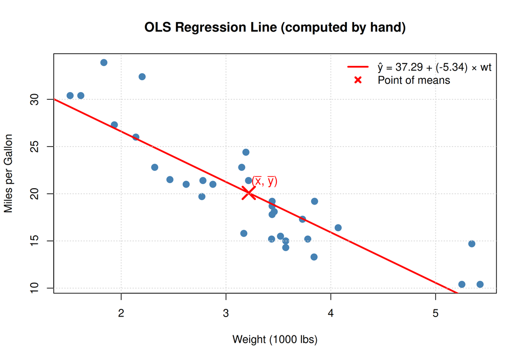

```r
plot(x, y, pch = 19, col = "steelblue", cex = 1.3,
     main = "OLS Regression Line (computed by hand)",
     xlab = "Weight (1000 lbs)", ylab = "Miles per Gallon")

abline(a = beta0_hat, b = beta1_hat, col = "red", lwd = 2.5)

points(x_bar, y_bar, pch = 4, col = "red", cex = 2.5, lwd = 3)

text(x_bar + 0.15, y_bar + 1.2,
     expression(paste("(", bar(x), ", ", bar(y), ")")), col = "red", cex = 1.1)

grid()

legend("topright",
       legend = c(paste0("ŷ = ", round(beta0_hat, 2), " + (",
                         round(beta1_hat, 2), ") × wt"), "Point of means"),
       col = c("red", "red"), lty = c(1, NA), pch = c(NA, 4),
       lwd = c(2.5, 3), bty = "n")
```

## Important property

The OLS regression line **always** passes through the point of means $(\bar{x}, \bar{y})$.

**Why?** From the formula:

$$\hat{\beta}_0 = \bar{y} - \hat{\beta}_1 \bar{x}$$

Substitute $x = \bar{x}$:

$$\hat{y} = \hat{\beta}_0 + \hat{\beta}_1 \bar{x} = (\bar{y} - \hat{\beta}_1 \bar{x}) + \hat{\beta}_1 \bar{x} = \bar{y}$$

## Visualizing the residuals

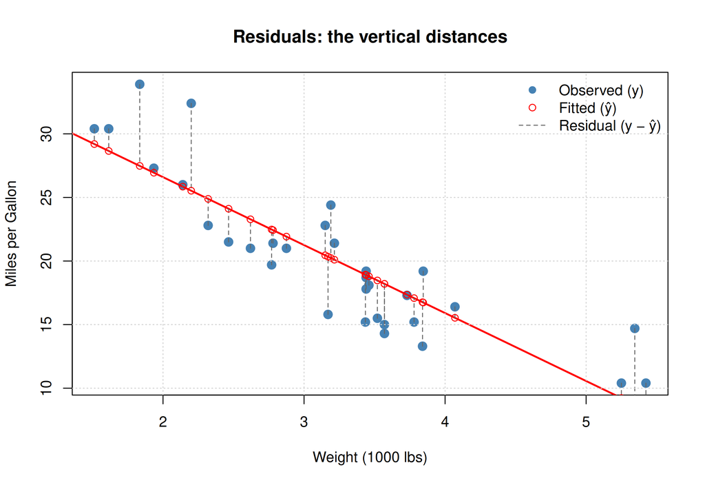

```r
y_hat <- beta0_hat + beta1_hat * x
resid <- y - y_hat

plot(x, y, pch = 19, col = "steelblue", cex = 1.3,
     main = "Residuals: the vertical distances",
     xlab = "Weight (1000 lbs)", ylab = "Miles per Gallon")
abline(a = beta0_hat, b = beta1_hat, col = "red", lwd = 2)
segments(x0 = x, y0 = y, x1 = x, y1 = y_hat, col = "gray40", lty = 2)
points(x, y_hat, pch = 1, col = "red", cex = 1)
grid()
legend("topright",
       legend = c("Observed (y)", "Fitted (ŷ)", "Residual (y − ŷ)"),
       col = c("steelblue", "red", "gray40"),
       pch = c(19, 1, NA), lty = c(NA, NA, 2), bty = "n")
```

## Properties of residuals

```r
cat("Sum of residuals:", round(sum(resid), 10), "\n")
```

```
Sum of residuals: 0
```

```r
cat("Cor(x, residuals):", round(cor(x, resid), 10), "\n")
```

```
Cor(x, residuals): 0
```

```r
cat("Mean of fitted values:", round(mean(y_hat), 4), "\n")
```

```
Mean of fitted values: 20.0906
```

```r
cat("Mean of y:            ", round(mean(y), 4), "\n")
```

```
Mean of y:             20.0906
```

```r
cat("  → They are equal!\n")
```

```
  → They are equal!
```

# Part IV: `lm()` — R Does It for Us

## Fitting and verifying

```r
model <- lm(mpg ~ wt, data = mtcars)
coef(model)
```

```
(Intercept)          wt
  37.285126   -5.344472
```

```r
cat("By hand:  β̂₀ =", round(beta0_hat, 4), "  β̂₁ =", round(beta1_hat, 4), "\n")
```

```
By hand:  β̂₀ = 37.2851   β̂₁ = -5.3445
```

```r
cat("lm():     β̂₀ =", round(coef(model)[1], 4),
    "  β̂₁ =", round(coef(model)[2], 4), "\n")
```

```
lm():     β̂₀ = 37.2851   β̂₁ = -5.3445
```

```r
cat("\n✓ They match!")
```

```
✓ They match!
```

# Part V: Inference by Hand

## Step 1: Estimate $\sigma^2$

$$\hat{\sigma}^2 = \frac{\text{SSR}}{n - 2} = \frac{\sum_{i=1}^{n} \hat{u}_i^2}{n - 2}$$

```r
SSR <- sum(resid^2)
df <- n - 2
sigma2_hat <- SSR / df
sigma_hat <- sqrt(sigma2_hat)

cat("SSR =", round(SSR, 4), "\n")
```

```
SSR = 278.3219
```

```r
cat("df  = n - 2 =", df, "\n")
```

```
df  = n - 2 = 30
```

```r
cat("σ̂²  =", round(sigma2_hat, 4), "\n")
```

```
σ̂²  = 9.2774
```

```r
cat("σ̂   =", round(sigma_hat, 4), " (Residual Standard Error)\n")
```

```
σ̂   = 3.0459  (Residual Standard Error)
```

## Step 2: Standard errors

$$\text{se}(\hat{\beta}_1) = \frac{\hat{\sigma}}{\sqrt{S_{xx}}}$$

```r
se_beta1 <- sigma_hat / sqrt(Sxx)

cat("se(β̂₁) =", round(se_beta1, 4), "\n")
```

```
se(β̂₁) = 0.5591
```

## Step 3: t-statistics and p-values

Under $H_0: \beta_j = 0$: $\quad t = \frac{\hat{\beta}_j}{\text{se}(\hat{\beta}_j)} \sim t_{n-2}$

```r
t_beta1 <- beta1_hat / se_beta1
p_beta1 <- 2 * pt(abs(t_beta1), df = df, lower.tail = FALSE)

cat(sprintf("         Estimate   Std.Error   t-value    p-value\n"))
```

```
         Estimate   Std.Error   t-value    p-value
```

```r
cat(sprintf("β̂₁  %10.4f  %10.4f  %8.3f   %.2e\n",
            beta1_hat, se_beta1, t_beta1, p_beta1))
```

```
β̂₁     -5.3445      0.5591    -9.559   1.29e-10
```

## Visualizing the t-test for $\beta_1$

```r
alpha <- 0.05
t_crit <- qt(1 - alpha/2, df = df)

curve(dt(x, df = df), from = -15, to = 15, n = 500, lwd = 2, col = "steelblue",
      main = expression(paste("t-test for ", H[0], ": ", beta[1], " = 0")),
      xlab = "t", ylab = "Density")

x_left <- seq(-15, -t_crit, length.out = 200)
x_right <- seq(t_crit, 15, length.out = 200)
polygon(c(x_left, rev(x_left)), c(dt(x_left, df), rep(0, 200)),
        col = rgb(1, 0, 0, 0.3), border = NA)
polygon(c(x_right, rev(x_right)), c(dt(x_right, df), rep(0, 200)),
        col = rgb(1, 0, 0, 0.3), border = NA)

abline(v = t_beta1, col = "red", lwd = 2.5, lty = 2)
text(t_beta1 + 1.5, 0.15, paste0("t = ", round(t_beta1, 2)),
     col = "red", cex = 1.2, font = 2)
abline(v = c(-t_crit, t_crit), col = "gray40", lty = 3)
legend("topleft",
       legend = c("t(30) distribution", "Rejection region (α = 0.05)", "Our t-statistic"),
       col = c("steelblue", rgb(1,0,0,0.3), "red"),
       lwd = c(2, 8, 2.5), lty = c(1, 1, 2), bty = "n")
```

[figure not shown]

## Confidence intervals (by hand)

$$\hat{\beta}_j \pm t_{\alpha/2, \, n-2} \cdot \text{se}(\hat{\beta}_j)$$

```r
cat("Critical value t_{0.025, 30} =", round(t_crit, 4), "\n\n")
```

```
Critical value t_{0.025, 30} = 2.0423
```

```r
ci_beta1 <- beta1_hat + c(-1, 1) * t_crit * se_beta1

cat("95% CI for β₁: [", round(ci_beta1[1], 4), ",", round(ci_beta1[2], 4), "]\n")
```

```
95% CI for β₁: [ -6.4863 , -4.2026 ]
```

```r
cat("\nNote: 0 is NOT inside the CI for β₁ → we reject H₀: β₁ = 0")
```

```
Note: 0 is NOT inside the CI for β₁ → we reject H₀: β₁ = 0
```

## Comparing with `summary()`

```r
summary(model)
```

```
Call:
lm(formula = mpg ~ wt, data = mtcars)

Residuals:
    Min      1Q  Median      3Q     Max
-4.5432 -2.3647 -0.1252  1.4096  6.8727

Coefficients:
            Estimate Std. Error t value Pr(>|t|)
(Intercept)  37.2851     1.8776  19.858  < 2e-16 ***
wt           -5.3445     0.5591  -9.559 1.29e-10 ***
---
Signif. codes:  0 '***' 0.001 '**' 0.01 '*' 0.05 '.' 0.1 ' ' 1

Residual standard error: 3.046 on 30 degrees of freedom
Multiple R-squared:  0.7528,    Adjusted R-squared:  0.7446
F-statistic: 91.38 on 1 and 30 DF,  p-value: 1.294e-10
```

## Confidence intervals: automatic

```r
confint(model)
```

```
                2.5 %    97.5 %
(Intercept) 33.450500 41.119753
wt          -6.486308 -4.202635
```

**Everything matches our hand calculations.**

## $R^2$ decomposition

```r
SST <- sum((y - y_bar)^2)
SSE <- sum((y_hat - y_bar)^2)
R2 <- 1 - SSR / SST
cat("R² =", round(R2, 4), "\n")
```

```
R² = 0.7528
```

```r
cat("Weight explains", round(R2 * 100, 1), "% of the variation in mpg.\n")
```

```
Weight explains 75.3 % of the variation in mpg.
```

## $R^2$ decomposition

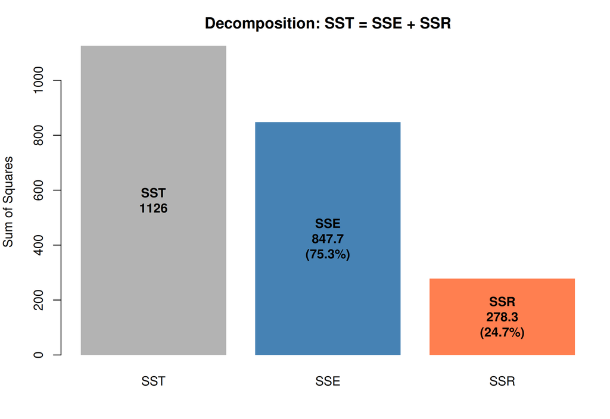

```r
par(mar = c(4, 4, 3, 1))
barplot(c(SST = SST, SSE = SSE, SSR = SSR),
        col = c("gray70", "steelblue", "coral"),
        main = "Decomposition: SST = SSE + SSR", ylab = "Sum of Squares", border = NA)
text(0.7, SST/2, paste0("SST\n", round(SST, 1)), cex = 1, font = 2)
text(1.9, SSE/2, paste0("SSE\n", round(SSE, 1), "\n(", round(SSE/SST*100,1), "%)"),
     cex = 1, font = 2)
text(3.1, SSR/2, paste0("SSR\n", round(SSR, 1), "\n(", round(SSR/SST*100,1), "%)"),
     cex = 1, font = 2)
```

# Part VI: ⭐ $\hat{\beta}_1$ Is a Random Variable

## The key insight

We said $\hat{\beta}_1 = \frac{S_{xy}}{S_{xx}}$ depends on the **sample**.

If we took a **different sample** from the same population, we would get a **different** $\hat{\beta}_1$.

Let’s **simulate** this!

- True model: $y = 5 + 3x + u$, where $u \sim N(0, 16)$
- Draw 1000 samples of size $n = 50$
- Estimate $\hat{\beta}_1$ each time

## Running the simulation

```r
beta0_true <- 5;  beta1_true <- 3;  sigma_true <- 4
set.seed(42)

n_sim <- 1000;  n_obs <- 50
x_sim <- runif(n_obs, min = 0, max = 10)

beta1_estimates <- numeric(n_sim)
beta0_estimates <- numeric(n_sim)

for (i in 1:n_sim) {
  u <- rnorm(n_obs, mean = 0, sd = sigma_true)
  y_sim <- beta0_true + beta1_true * x_sim + u
  fit <- lm(y_sim ~ x_sim)
  beta0_estimates[i] <- coef(fit)[1]
  beta1_estimates[i] <- coef(fit)[2]
}

cat("Done:", n_sim, "regressions, each with n =", n_obs, "observations.\n")
```

```
Done: 1000 regressions, each with n = 50 observations.
```

## 20 samples → 20 different lines

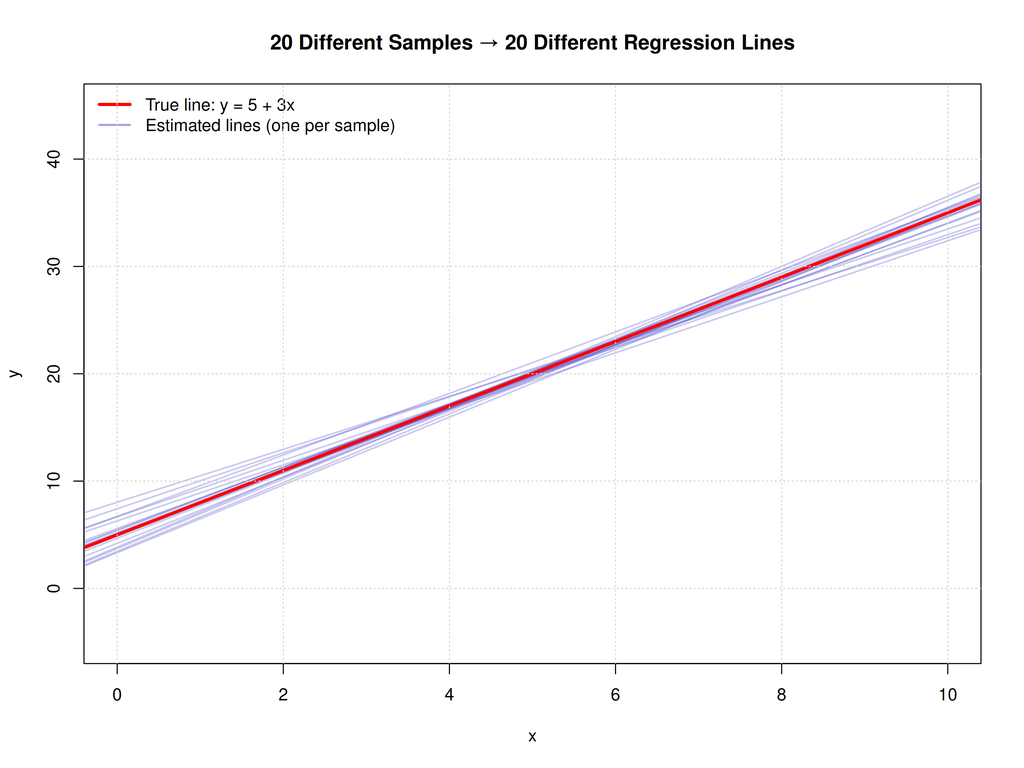

```r
plot(NULL, xlim = c(0, 10), ylim = c(-5, 45),
     main = "20 Different Samples → 20 Different Regression Lines",
     xlab = "x", ylab = "y")
for (i in 1:20) {
  abline(a = beta0_estimates[i], b = beta1_estimates[i],
         col = rgb(0.3, 0.3, 0.8, 0.3), lwd = 1.5)
}
abline(a = beta0_true, b = beta1_true, col = "red", lwd = 3)
legend("topleft",
       legend = c("True line: y = 5 + 3x", "Estimated lines (one per sample)"),
       col = c("red", rgb(0.3, 0.3, 0.8, 0.5)), lwd = c(3, 2), bty = "n")
grid()
```

## The sampling distribution of $\hat{\beta}_1$

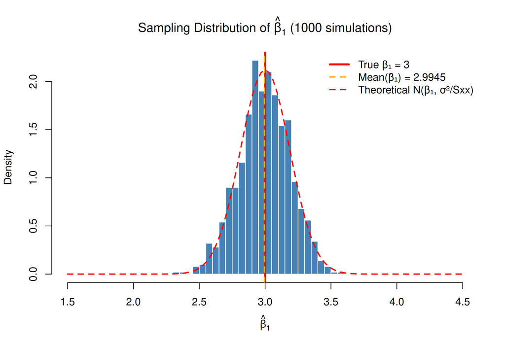

```r
se_theory <- sigma_true / sqrt(sum((x_sim - mean(x_sim))^2))

hist(beta1_estimates, breaks = 40, freq = FALSE,
     col = "steelblue", border = "white",
     main = expression(paste("Sampling Distribution of ", hat(beta)[1],
                             " (1000 simulations)")),
     xlab = expression(hat(beta)[1]),
     xlim = c(beta1_true - 1.5, beta1_true + 1.5))
abline(v = beta1_true, col = "red", lwd = 3)
abline(v = mean(beta1_estimates), col = "orange", lwd = 2, lty = 2)
curve(dnorm(x, mean = beta1_true, sd = se_theory), add = TRUE,
      col = "red", lwd = 2, lty = 2)
legend("topright",
       legend = c(paste0("True β₁ = ", beta1_true),
                  paste0("Mean(β̂₁) = ", round(mean(beta1_estimates), 4)),
                  "Theoretical N(β₁, σ²/Sxx)"),
       col = c("red", "orange", "red"),
       lwd = c(3, 2, 2), lty = c(1, 2, 2), bty = "n")
```

## Unbiasedness confirmed

```r
cat("True β₁              =", beta1_true, "\n")
```

```
True β₁              = 3
```

```r
cat("Mean of β̂₁           =", round(mean(beta1_estimates), 4), "\n")
```

```
Mean of β̂₁           = 2.9945
```

```r
cat("  → UNBIASED: E[β̂₁] ≈ β₁ ✓\n\n")
```

```
  → UNBIASED: E[β̂₁] ≈ β₁ ✓
```

```r
cat("Std Dev of β̂₁ (simulated) =", round(sd(beta1_estimates), 4), "\n")
```

```
Std Dev of β̂₁ (simulated) = 0.1932
```

```r
cat("Std Dev of β̂₁ (theory)    =", round(se_theory, 4), "\n")
```

```
Std Dev of β̂₁ (theory)    = 0.1882
```

```r
cat("  → MATCHES: se(β̂₁) = σ/√Sxx ✓\n\n")
```

```
  → MATCHES: se(β̂₁) = σ/√Sxx ✓
```

```r
cat("True β₀              =", beta0_true, "\n")
```

```
True β₀              = 5
```

```r
cat("Mean of β̂₀           =", round(mean(beta0_estimates), 4), "\n")
```

```
Mean of β̂₀           = 5.022
```

```r
cat("  → UNBIASED: E[β̂₀] ≈ β₀ ✓\n")
```

```
  → UNBIASED: E[β̂₀] ≈ β₀ ✓
```

## Key takeaways from the simulation

- Each sample gives a **different** $\hat{\beta}_1$ — the estimator is a **random variable**
- On average, $\hat{\beta}_1$ equals the true $\beta_1$ → **unbiasedness**
- The spread of $\hat{\beta}_1$ is captured by the **standard error**
- The histogram matches the theoretical normal → this **justifies our t-tests and CIs**

# Part VII: What Affects Precision?

## The formula tells us everything

$$\text{se}(\hat{\beta}_1) = \frac{\sigma}{\sqrt{S_{xx}}}$$

Three things affect precision:

1. **Sample size** $n$ → more data → larger $S_{xx}$ → smaller se
2. **Spread of** $x$ → more variation → larger $S_{xx}$ → smaller se
3. **Error variance** $\sigma^2$ → noisier data → larger se

## Effect of sample size

```r
set.seed(123)
sample_sizes <- c(20, 50, 100, 500)
n_reps <- 1000

par(mfrow = c(2, 2), mar = c(4, 4, 3, 1))
for (nn in sample_sizes) {
  x_temp <- runif(nn, 0, 10)
  b1_vec <- numeric(n_reps)
  for (j in 1:n_reps) {
    u_temp <- rnorm(nn, 0, sigma_true)
    y_temp <- beta0_true + beta1_true * x_temp + u_temp
    b1_vec[j] <- coef(lm(y_temp ~ x_temp))[2]
  }
  hist(b1_vec, breaks = 35, freq = FALSE, col = "steelblue", border = "white",
       main = paste0("n = ", nn, "  (sd = ", round(sd(b1_vec), 3), ")"),
       xlab = expression(hat(beta)[1]), xlim = c(1.5, 4.5))
  abline(v = beta1_true, col = "red", lwd = 2)
}
```

[figure not shown]

## Effect of noise level $\sigma$

```r
set.seed(456)
sigmas <- c(1, 4, 8, 16)
nn_fixed <- 50;  x_temp <- runif(nn_fixed, 0, 10)

par(mfrow = c(2, 2), mar = c(4, 4, 3, 1))
for (ss in sigmas) {
  b1_vec <- numeric(n_reps)
  for (j in 1:n_reps) {
    u_temp <- rnorm(nn_fixed, 0, ss)
    y_temp <- beta0_true + beta1_true * x_temp + u_temp
    b1_vec[j] <- coef(lm(y_temp ~ x_temp))[2]
  }
  hist(b1_vec, breaks = 35, freq = FALSE, col = "coral", border = "white",
       main = bquote(sigma == .(ss) ~ " (sd = " * .(round(sd(b1_vec), 3)) * ")"),
       xlab = expression(hat(beta)[1]), xlim = c(-1, 7))
  abline(v = beta1_true, col = "red", lwd = 2)
}
```

[figure not shown]

## Observation

More data → **tighter** distribution.

More noise → **wider** distribution.

In **both cases**, the estimator remains **centered on the true value** (unbiased).

# Part VIII: Subsampling from Real Data

## Different subsamples, different estimates

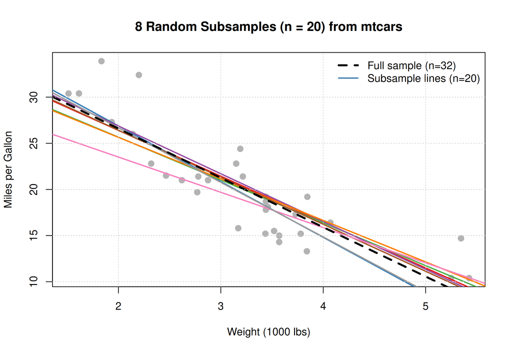

```r
set.seed(2024)
plot(mtcars$wt, mtcars$mpg, pch = 19, col = "gray70", cex = 1.2,
     main = "8 Random Subsamples (n = 20) from mtcars",
     xlab = "Weight (1000 lbs)", ylab = "Miles per Gallon")

colors <- c("#E41A1C", "#377EB8", "#4DAF4A", "#984EA3",
            "#FF7F00", "#A65628", "#F781BF", "#999999")
sub_betas <- numeric(8)
for (i in 1:8) {
  idx <- sample(1:32, size = 20, replace = FALSE)
  fit_sub <- lm(mpg ~ wt, data = mtcars[idx, ])
  abline(fit_sub, col = colors[i], lwd = 2)
  sub_betas[i] <- coef(fit_sub)[2]
}
abline(model, col = "black", lwd = 3, lty = 2)
legend("topright",
       legend = c("Full sample (n=32)", "Subsample lines (n=20)"),
       col = c("black", "steelblue"), lwd = c(3, 2), lty = c(2, 1), bty = "n")
grid()
```

# Part IX: Residual Diagnostics

## Four diagnostic plots

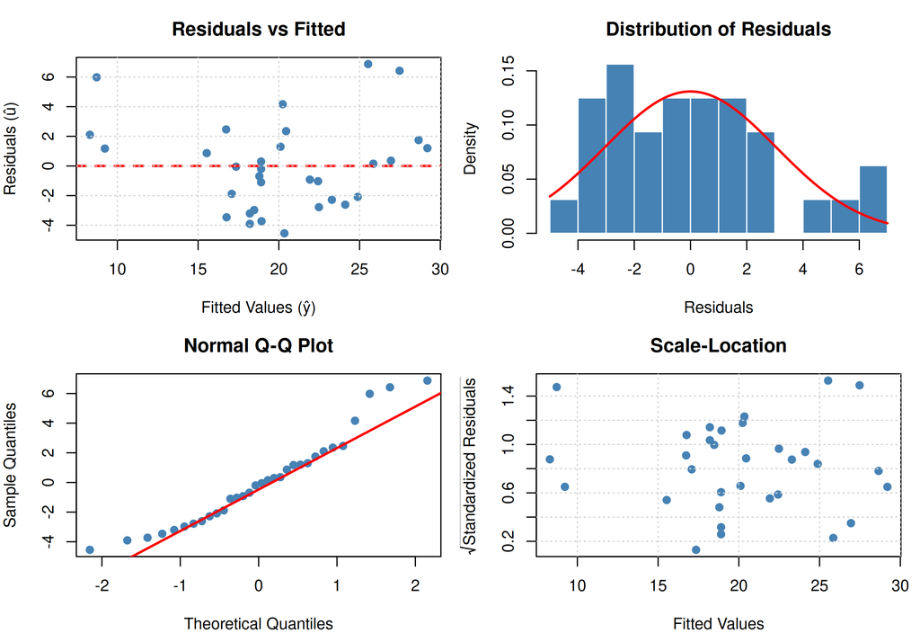

```r
par(mfrow = c(2, 2), mar = c(4, 4, 3, 1))

plot(fitted(model), residuals(model), pch = 19, col = "steelblue",
     main = "Residuals vs Fitted", xlab = "Fitted Values (ŷ)", ylab = "Residuals (û)")
abline(h = 0, col = "red", lwd = 2, lty = 2); grid()

hist(residuals(model), breaks = 10, freq = FALSE,
     col = "steelblue", border = "white",
     main = "Distribution of Residuals", xlab = "Residuals")
curve(dnorm(x, mean = 0, sd = sigma_hat), add = TRUE, col = "red", lwd = 2)

qqnorm(residuals(model), pch = 19, col = "steelblue", main = "Normal Q-Q Plot")
qqline(residuals(model), col = "red", lwd = 2)

plot(fitted(model), sqrt(abs(rstandard(model))), pch = 19, col = "steelblue",
     main = "Scale-Location", xlab = "Fitted Values",
     ylab = expression(sqrt("Standardized Residuals")))
grid()
```

## How to read them

- **Residuals vs Fitted:** Random scatter around 0 = good. Curve or funnel = problems.
- **Histogram / Q-Q:** Check approximate normality.
- **Scale-Location:** Roughly constant spread = homoscedasticity.

# Part X: Confidence & Prediction Bands

## Two types of intervals

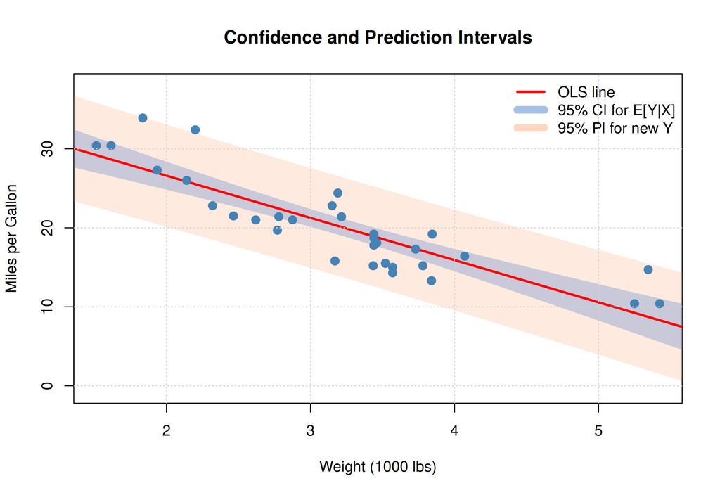

```r
x_grid <- data.frame(wt = seq(min(mtcars$wt) - 0.2, max(mtcars$wt) + 0.2,
                               length.out = 200))
pred_ci <- predict(model, newdata = x_grid, interval = "confidence")
pred_pi <- predict(model, newdata = x_grid, interval = "prediction")

plot(mtcars$wt, mtcars$mpg, pch = 19, col = "steelblue", cex = 1.2,
     main = "Confidence and Prediction Intervals",
     xlab = "Weight (1000 lbs)", ylab = "Miles per Gallon",
     ylim = c(min(pred_pi[,"lwr"]) - 1, max(pred_pi[,"upr"]) + 1))
polygon(c(x_grid$wt, rev(x_grid$wt)),
        c(pred_pi[,"lwr"], rev(pred_pi[,"upr"])),
        col = rgb(1, 0.6, 0.4, 0.2), border = NA)
polygon(c(x_grid$wt, rev(x_grid$wt)),
        c(pred_ci[,"lwr"], rev(pred_ci[,"upr"])),
        col = rgb(0.3, 0.5, 0.8, 0.3), border = NA)
lines(x_grid$wt, pred_ci[,"fit"], col = "red", lwd = 2.5)
points(mtcars$wt, mtcars$mpg, pch = 19, col = "steelblue", cex = 1.2)
legend("topright",
       legend = c("OLS line", "95% CI for E[Y|X]", "95% PI for new Y"),
       col = c("red", rgb(0.3,0.5,0.8,0.5), rgb(1,0.6,0.4,0.4)),
       lwd = c(2.5, 8, 8), bty = "n")
grid()
```

## Interpretation

**Confidence interval** (blue): Where the **true regression line** likely is. Narrower near $\bar{x}$.

**Prediction interval** (orange): Where a **new observation** would fall. Always wider because it includes both line uncertainty **and** the noise $\sigma^2$.

# Summary

## Key R functions

| Task | Code |
| --- | --- |
| Fit model | `lm(y ~ x, data = df)` |
| Coefficients | `coef(model)` |
| Full output | `summary(model)` |
| CIs | `confint(model)` |
| Fitted values | `fitted(model)` |
| Residuals | `residuals(model)` |
| Predict | `predict(model, newdata)` |
| $R^2$ | `summary(model)$r.squared` |

## Takeaways

1. **OLS minimizes** the sum of squared residuals
2. **$\hat{\beta}_1$ is a random variable** — it changes with the sample
3. **Unbiasedness:** $E[\hat{\beta}_1] = \beta_1$ — on average, OLS gets it right
4. **Standard errors** decrease with more data and less noise
5. **t-tests and CIs** follow from the sampling distribution
6. **R makes all of this easy** — but understanding what’s behind it is essential!